# s10: Plot theming exercises

```r
suppressPackageStartupMessages(library(tidyverse))
library(gapminder)
```

# Saving Graphs to File

- Don’t use the mouse
- Use `ggsave` for ggplot
  - Practice by saving the following plot to file:

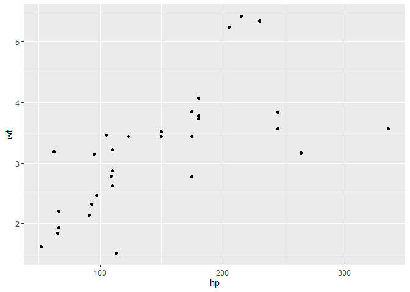

```r
ggplot(mtcars, aes(hp, wt)) +
    geom_point()
```

```r
ggsave("hp_and_wt.png")
```

- Base R way: print plots “to screen”, sandwiched between `pdf()`/`jpeg()`/`png()`… and `dev.off()`.
- Vector vs. raster: Images are stored on your computer as either *vector* or *raster*.
  - **Raster**: an `n` by `m` grid of pixels, each with its own colour. `jpeg`, `png`, `gif`, `bmp`.
  - **Vector**: represented as shapes and lines. `pdf`, [`svg`](https://www.w3schools.com/graphics/svg_intro.asp).
  - For tips: [“10 tips for making your R graphics look their best”"](http://blog.revolutionanalytics.com/2009/01/10-tips-for-making-your-r-graphics-look-their-best.html).

# Scales; Color

Scale functions in `ggplot2` take the form `scale_[aesthetic]_[mapping]()`.

Let’s first focus on the following plot:

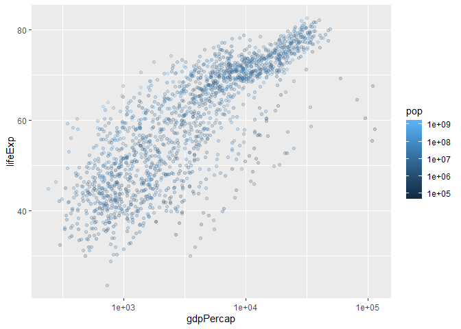

```r
p_scales <- ggplot(gapminder, aes(gdpPercap, lifeExp)) +
     geom_point(aes(colour=pop), alpha=0.2)
p_scales +
    scale_x_log10() +
    scale_colour_continuous(trans="log10")
```

1. Change the y-axis tick mark spacing to 10; change the colour spacing to include all powers of 10.

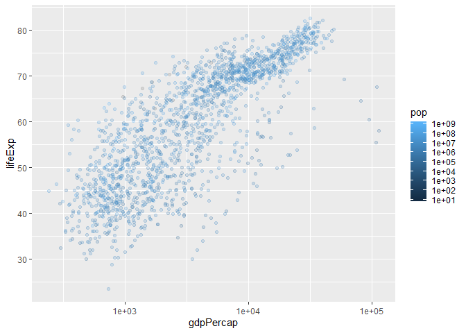

```r
p_scales +
    scale_x_log10() +
    scale_colour_continuous(
        trans  = "log10",
        breaks = c(1e+01,1e+02,1e+03,1e+04,1e+05,1e+06,1e+07,1e+08,1e+09),
        limits = c(10,1e+09)
    ) +
    scale_y_continuous(breaks=c(10,20,30,40,50,60,70,80))
```

```r
#see the next example for a better way to do this with vectors
```

2. Specify `scales::*_format` in the `labels` argument of a scale function to do the following:
   - Change the x-axis labels to dollar format (use `scales::dollar_format()`)
   - Change the colour labels to comma format (use `scales::comma_format()`)

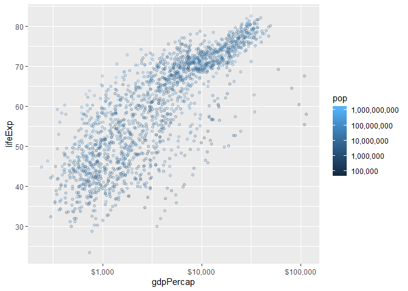

```r
library(scales)
p_scales +
    scale_x_log10(labels=scales::dollar_format()) +
    scale_colour_continuous(
        trans  = "log10",
        breaks = 10^(1:10),
        labels = scales::comma_format()
    ) +
    scale_y_continuous(breaks=10*(1:10))
```

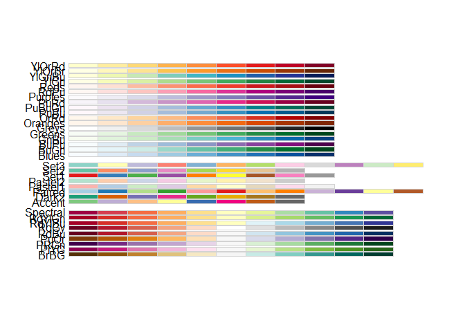

```r
## All palettes the come with RColorBrewer:
RColorBrewer::display.brewer.all()
```

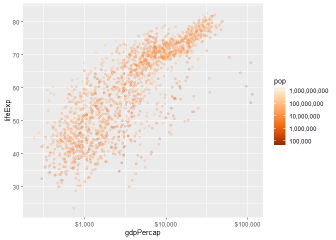

```r
p_scales +
    scale_x_log10(labels=dollar_format()) +
    scale_color_distiller(
        trans   = "log10",
        breaks  = 10^(1:10),
        labels  = comma_format(),
        palette = "Oranges"
    ) +
    scale_y_continuous(breaks=10*(1:10))
```

4. Use `viridis` to change the colour to a colour-blind friendly scheme
   - Hint: add `scale_colour_viridis_c` (`c` stands for continuous; `d` discrete).
   - You can choose a palette with `option`.

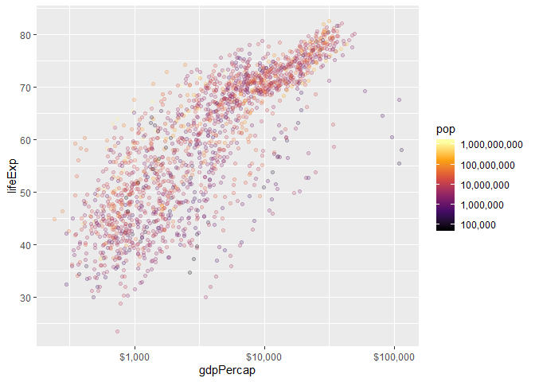

```r
p_scales +
    scale_x_log10(labels=dollar_format()) +
    scale_color_viridis_c(
        trans   = "log10",
        breaks  = 10^(1:10),
        labels  = comma_format(),
        option = "B"
    ) +
    scale_y_continuous(breaks=10*(1:10))
```